# Predicting the distribution of an invasive duckweed species

### Randomly sample points

(same number as our observed points) inside the buffer to create pseudo-absences, or hypothetical areas where species was not found. Divide background dataset into training and testing

### Run model and check variable contribution

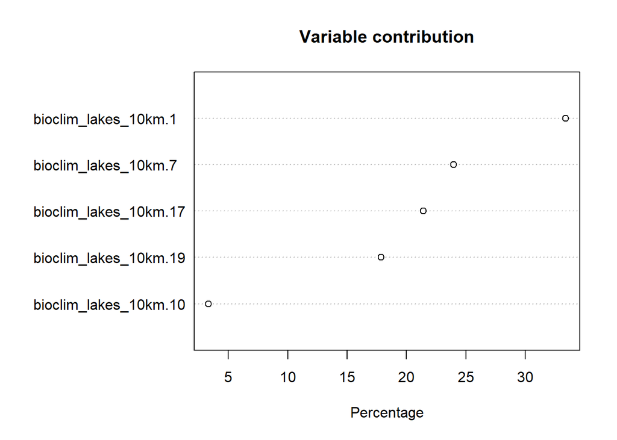

```r
set.seed(202307)

xm4 <- maxent(modelEnv, pres_train, linear=true, quadratic=true, product=false,
              threshold=false, hinge=false)
plot(xm4)
```

### Check potential correlations between bioclimatic variables

|  | Var1 | Var2 | Freq |
| --- | --- | --- | --- |
| 3 | bioclim_lakes_10km.10 | bioclim_lakes_10km.1 | 0.95 |
| 11 | bioclim_lakes_10km.1 | bioclim_lakes_10km.10 | 0.95 |
| 20 | bioclim_lakes_10km.19 | bioclim_lakes_10km.17 | 0.96 |
| 24 | bioclim_lakes_10km.17 | bioclim_lakes_10km.19 | 0.96 |

### Select variables which contribute the most and are unrelated to each other

- To reflect thermal dependency of duckweeds in terms of population growth:

BIO 1 = Mean annual temperature (Armitage, 2022)

BIO 7 = Annual range of temperature (Armitage, 2022)

- To account for the dependency on precipitation (duckweeds are rare in places with high or very low precipitation; FNA, 2000):

BIO17 = Precipitation of Driest Quarter

### Create several candidate models using different combinations of parameters

```r
# https://jamiemkass.github.io/ENMeval/articles/ENMeval-2.0-vignette.html
set.seed(202308)
library(ENMeval)
e.mx.l <- ENMevaluate(occs = pres_train, envs = modelEnv, bg = backg_train,
                      occs.testing = pres_test,
                      algorithm = 'maxnet', partitions = 'block',
                      tune.args = list(fc = c("L","LQ"), rm = seq(0.5, 4, by = 0.5)))
```

### Overall results

| Features | Regularization multiplier | Training AUC | Mean testing AUC | AICc | Delta AICc | Parameters |
| --- | --- | --- | --- | --- | --- | --- |
| L | 0.5 | 0.71 | 0.68 | 10284.06 | 859.35 | 3 |
| LQ | 0.5 | 0.90 | 0.81 | 9424.71 | 0.00 | 6 |
| L | 1 | 0.71 | 0.68 | 10280.87 | 856.16 | 3 |
| LQ | 1 | 0.89 | 0.78 | 9537.03 | 112.32 | 6 |
| L | 1.5 | 0.71 | 0.68 | 10278.01 | 853.30 | 3 |
| LQ | 1.5 | 0.88 | 0.77 | 9634.14 | 209.43 | 6 |
| L | 2 | 0.72 | 0.68 | 10275.09 | 850.38 | 3 |
| LQ | 2 | 0.87 | 0.77 | 9718.43 | 293.72 | 6 |
| L | 2.5 | 0.72 | 0.68 | 10272.26 | 847.55 | 3 |
| LQ | 2.5 | 0.86 | 0.77 | 9798.65 | 373.94 | 6 |
| L | 3 | 0.72 | 0.68 | 10269.52 | 844.81 | 3 |
| LQ | 3 | 0.85 | 0.76 | 9877.12 | 452.41 | 6 |
| L | 3.5 | 0.72 | 0.68 | 10266.88 | 842.17 | 3 |
| LQ | 3.5 | 0.83 | 0.76 | 9945.60 | 520.89 | 5 |
| L | 4 | 0.71 | 0.68 | 10264.32 | 839.61 | 3 |
| LQ | 4 | 0.82 | 0.75 | 10009.54 | 584.84 | 5 |

### Select models with lowest AICc and highest mean testing AUC. In this case, a single model has both features

Lowest AICc

|  | Features | Regularization multiplier | Training AUC | Mean testing AUC | AICc | Delta AICc | Parameters |
| --- | --- | --- | --- | --- | --- | --- | --- |
| 2 | LQ | 0.5 | 0.9 | 0.81 | 9424.71 | 0 | 6 |

Highest mean testing AUC

|  | Features | Regularization multiplier | Training AUC | Mean testing AUC | AICc | Delta AICc | Parameters |
| --- | --- | --- | --- | --- | --- | --- | --- |
| 2 | LQ | 0.5 | 0.9 | 0.81 | 9424.71 | 0 | 6 |

### TSS metrics are calculated for the following subsets:

- Complete set of original training data from around the globe, except Europe (Train)
- Data from Europe (withheld from cross-validation training and testing, Test)

```r
e_2train = evaluate(pres_train, backg_train, model1, modelEnv)
e_2test = evaluate(pres_test, backg_test, model1, modelEnv)

e_2tss_train <- max(e_2train@TPR + e_2train@TNR) - 1
e_2tss_test <- max(e_2test@TPR + e_2test@TNR) - 1
```

| Model | TSS.train | TSS.test |
| --- | --- | --- |
| Selected model | 0.67 | 0.83 |

### Plot response curves for best model

BIO 1 = mean annual temperature

BIO 7 = annual temperature variation

Bio 17 = precipitation of driest quarter

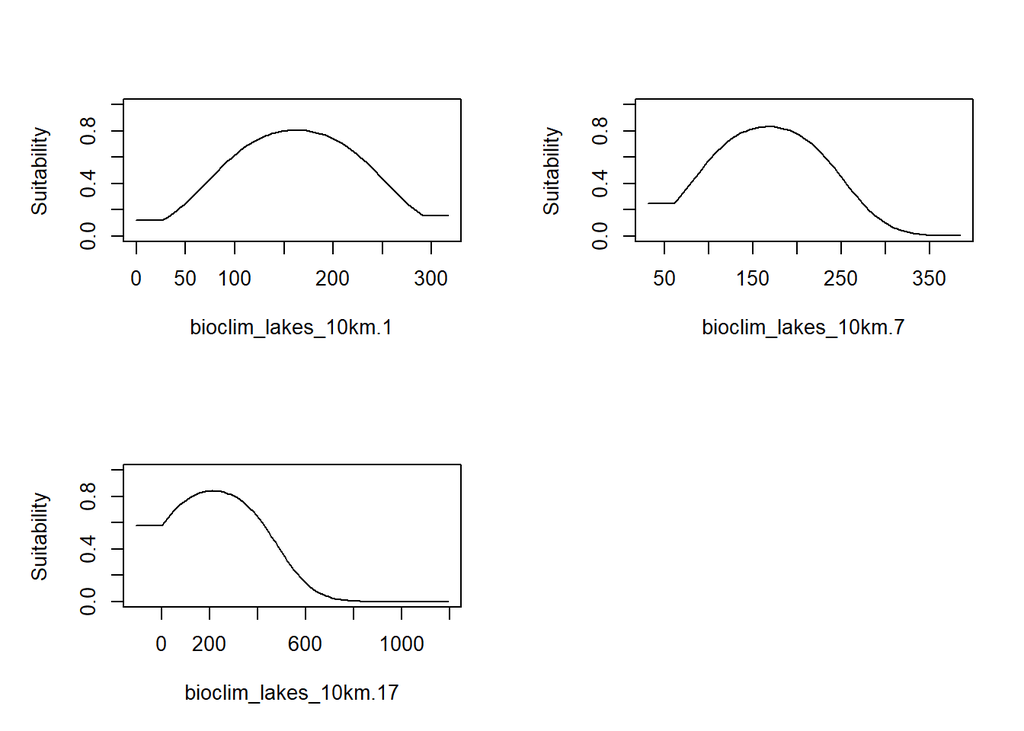

```r
plot(model1, type = "cloglog",
     ylab=tools::toTitleCase("Suitability"))
```

### Plot model predictions

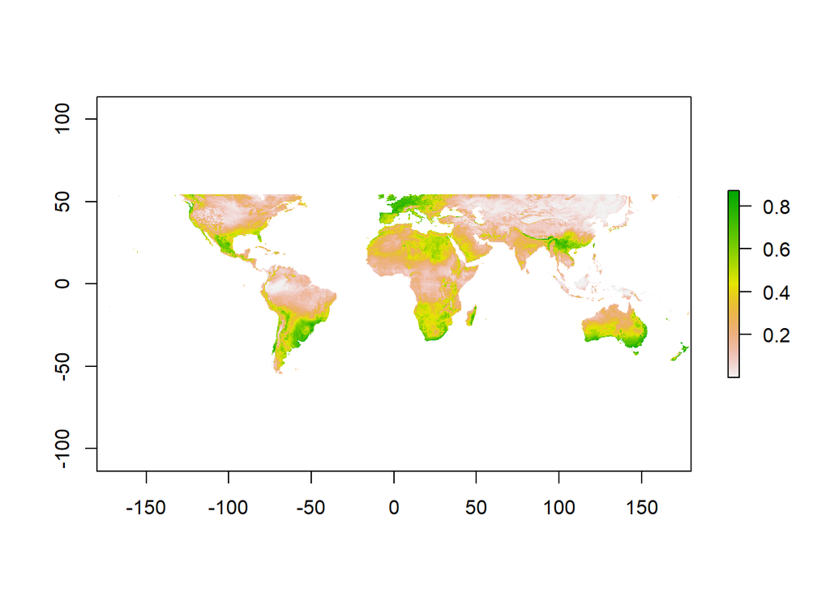

### Add occurrence (training data) and background points to prediction plot

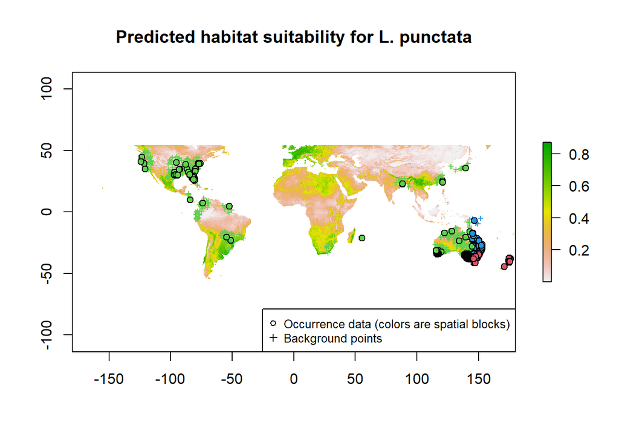

### Model predictions for Europe

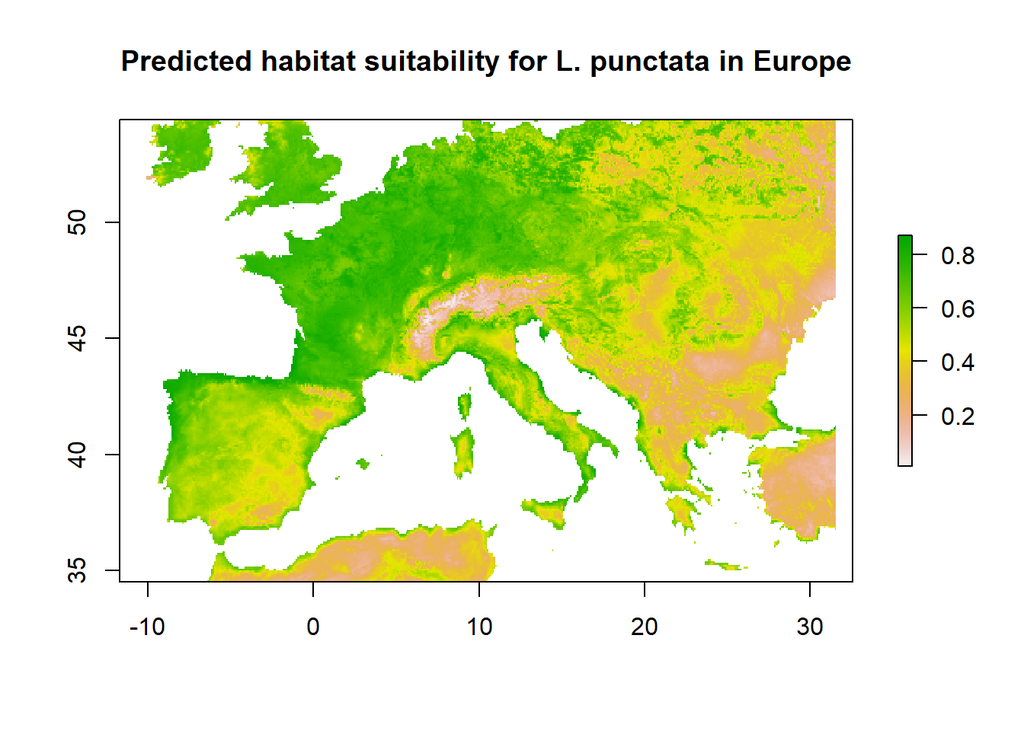

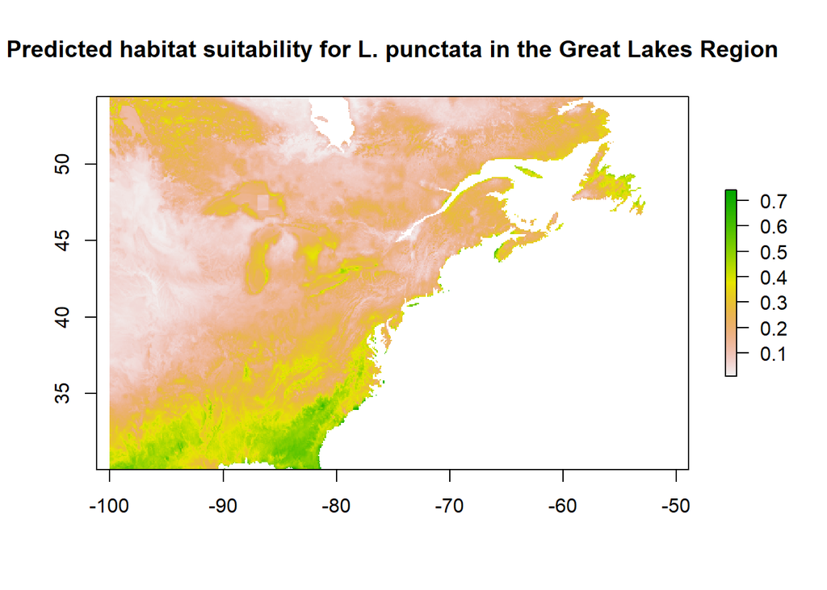

### Model predictions for North America

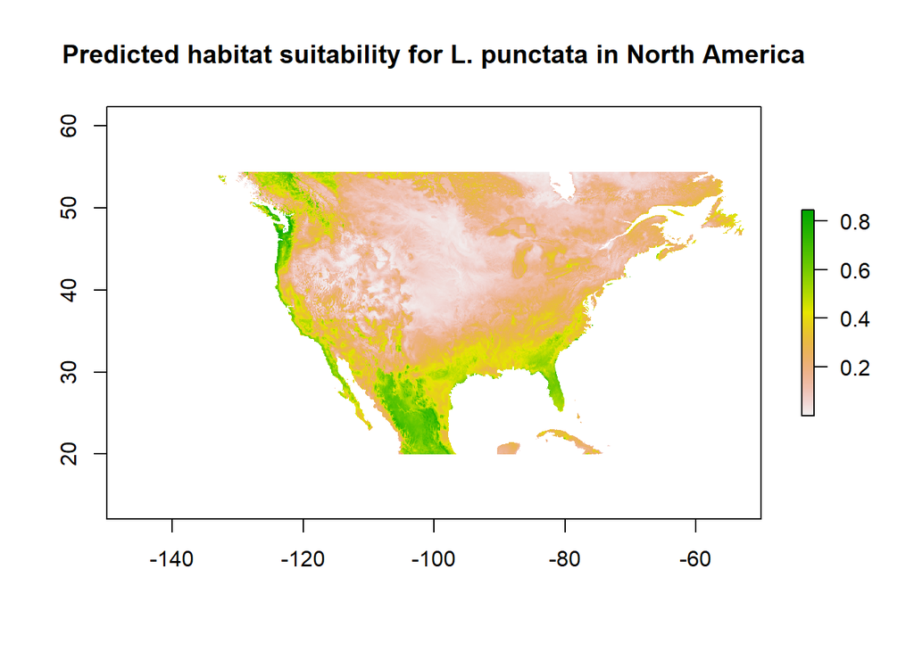